# Inferencia para una muestra

Marta Venegas Pardo

# 1 Introducción

Sea el siguiente contraste de hipótesis, para un nivel de confianza $\alpha$:
$$H_0 : X \sim N(\mu,\sigma^2) \\ H_1 : X \neq N(\mu,\sigma^2)$$

## 1.1 Test Shapiro-Wilk:

En el paquete base con la instrucción **shapiro.test**

Creamos una variable aleatoria:

```r
set.seed(12345)
x=rnorm(15,0,1)
x
```

```
##  [1]  0.5855288  0.7094660 -0.1093033 -0.4534972  0.6058875 -1.8179560
##  [7]  0.6300986 -0.2761841 -0.2841597 -0.9193220 -0.1162478  1.8173120
## [13]  0.3706279  0.5202165 -0.7505320
```

Test de Shapiro Wilk para ver si mi variable aleatoria sigue una normal.

```r
shapiro.test(x)
```

```
##
##  Shapiro-Wilk normality test
##
## data:  x
## W = 0.96152, p-value = 0.7189
```

Tenemos que el p-valor=0.7189 por lo que acepto la hipótesis nula, es decir, los datos provienen de una variable aleatoria con distribución normal.

Acepto $H_0$

## 1.2 Test de normalidad en el paquete fBasics

Instalamos la librería.

```r
library(fBasics)
```

Test de normalidad:

```r
ksnormTest(x)
```

```
##
## Title:
##  One-sample Kolmogorov-Smirnov test
##
## Test Results:
##   STATISTIC:
##     D: 0.1724
##   P VALUE:
##     Alternative Two-Sided: 0.7025
##     Alternative      Less: 0.5779
##     Alternative   Greater: 0.3683
##
## Description:
##  Thu Apr 29 23:42:57 2021 by user:
```

Aceptamos $H_0$ en todos los casos, la distribución de la variable X se aproxima a una Normal Univariante.

En el paquete *nortest* vienen recogido otros test.

# 2 Ejercicio 1

Dibujar la densidad de la t-Student bajo H0, los cuantiles que definen los puntos críticos y el valor del estadístico.

Para hacer contrastes paramétricos deberíamos hacer antes contrastes de normalidad.

## 2.1 Estudiar gráficamente la normalidad.

```r
x =c(17,12,15,16,15,11,12,13,20,16,14,13,10,13,11,10,13)
length(x)
```

```
## [1] 17
```

```r
#anador_tidy(x)
```

```r
summary(x)
```

```
##    Min. 1st Qu.  Median    Mean 3rd Qu.    Max.
##   10.00   12.00   13.00   13.59   15.00   20.00
```

Realizamos el siguiente contraste de hipótesis:

$$\begin{array}{l}
H_0: \mu = 15 \\
H_0: \not= 15
\end{array}$$

Se pueden utilizar test paramétricos:

```r
t.test(x)
```

```
##
##  One Sample t-test
##
## data:  x
## t = 20.978, df = 16, p-value = 4.576e-13
## alternative hypothesis: true mean is not equal to 0
## 95 percent confidence interval:
##  12.21512 14.96136
## sample estimates:
## mean of x
##  13.58824
```

Si no ponemos nada, estudia si la media es 0 o no. Por ello aparece un p-valor muy pequeño. Debemos fijar $H_0: \mu=15$

Luego,

```r
t.test(x, mu=15)
```

```
##
##  One Sample t-test
##
## data:  x
## t = -2.1796, df = 16, p-value = 0.04458
## alternative hypothesis: true mean is not equal to 15
## 95 percent confidence interval:
##  12.21512 14.96136
## sample estimates:
## mean of x
##  13.58824
```

```r
# t.test(x, mu=15, level=0.99, alternative="less") Podemos cambiar el nivel de confianza para el intervalo y hacer contrastes mayor menor, opción greater
```

Con las otras opciones: (revisar y escribir bien)

$$\begin{array}{l}
H_0: \mu \leq 15 \\
H_0: \mu > 15
\end{array}$$

```r
library(ggplot2)
funcion_g_dt_test=function(x,mu_=15){
#mu_=15
datos=data.frame(X=x)
resul=t.test(datos$X,mu=mu_)
  ggplot(datos,aes(x=X)) +
  stat_function(aes(x=seq(-4,4,length=length(X))),
                fun=dt,args = list(df=length(datos$X)-1),color="black")+
  geom_vline(aes(xintercept=resul$statistic),color="blue",
             linetype="dotted",size=1.4)+
  geom_vline(aes(xintercept=qt(0.025,df=resul$parameter)),color="red",
             linetype="dashed",size=1.4)+
  geom_vline(aes(xintercept=qt(0.975,df=resul$parameter)),color="red",
             linetype="dashed",size=1.4)
}
```

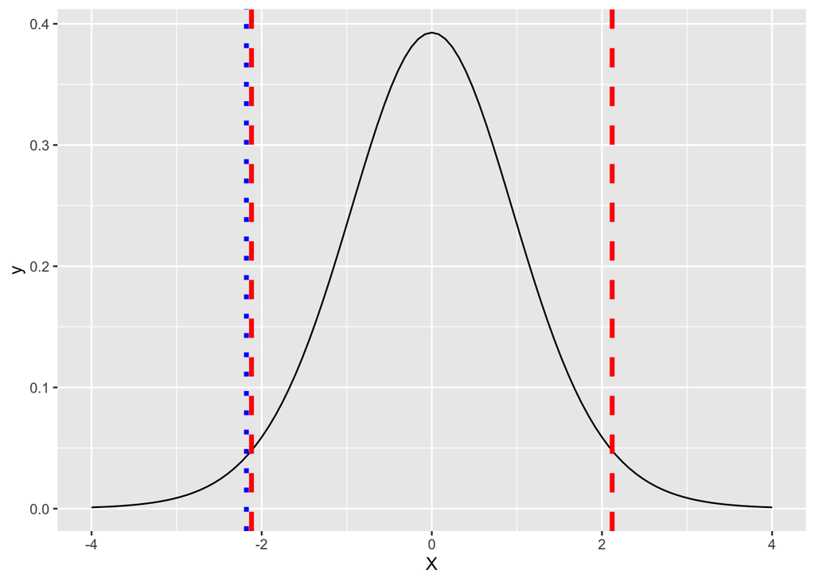

```r
funcion_g_dt_test(x,mu_ = 15)
```

## 2.2 Ejercicio 2

```r
#func_g_dt_test_unilateral(x,mu_=15)
```

## 2.3 Ejercicio 3

Se desea contrastar $H_0$ precio medio igual a 500

```r
x=c(110,12,2.5,98,1017,540,54,4.3,150,432)
#ananor_tidy
```

No podemos usar la estadística paramétrica para estudiar esta muestra, habrá que emplear técnicas no paramétricas, como el test de rangos signos de Wilcoxson.

```r
wilcox.test(x,conf.int = TRUE,mu=500)
```

```
##
##  Wilcoxon signed rank test
##
## data:  x
## V = 11, p-value = 0.1055
## alternative hypothesis: true location is not equal to 500
## 95 percent confidence interval:
##   33.0 514.5
## sample estimates:
## (pseudo)median
##            150
```

El intervalo incluye al valor 500, el pvalor= 0.1055, acepto $H_0$

### 2.3.1 Apartado a

Calcular directamente W+ (test de rango-signo de Wilcoxon)

```r
#W+=suma(rangos(|Xi|),xi>0)
# H0 = mu=0
mu_=500
rangos=rank(abs(x-mu_))
rangos[(x-mu_) >0]
```

```
## [1] 10  1
```

```r
(est.w=sum(rangos[(x-mu_) >0]))
```

```
## [1] 11
```

Obtenemos el valor V del test anterior.

### 2.3.2 Apartado b

Dibujar la función de probabilidad (densidad) de W+ para esta n, usando *dsignrank*

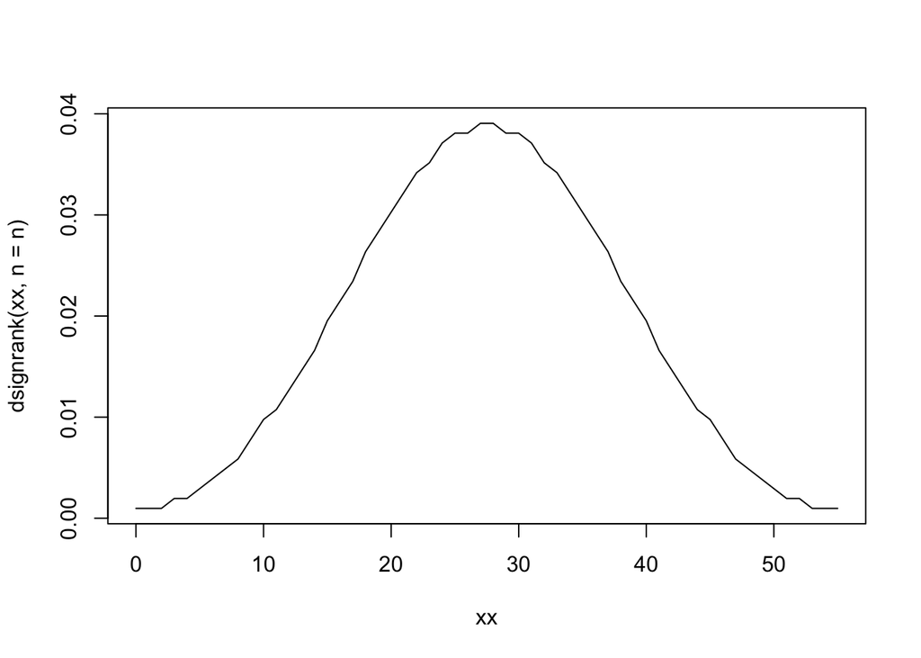

```r
#dsignrank()
n=length(x)
xx=seq(0,n*(n+1)/2,1)
plot(xx,dsignrank(xx,n=n),type="l")
```

Tengo en el eje X las x y en el Y la f(x).

Esperanza

```r
# E[W+]
# Un estiamdor sería:
sum(xx*dsignrank(xx,n=n))
```

```
## [1] 27.5
```

Varianza

```r
sum(xx^2*dsignrank(xx,n=n))-(n*(n+1)/4)^2
```

```
## [1] 96.25
```

## 2.4 Ejercicio 4

$$\begin{array}{l}
H_0: p= \dfrac{3}{4} \\
H_0: p \not= \dfrac{3}{4}
\end{array}$$

Con el test binomial, realizamos el contraste bilateral

```r
binom.test(c(682,243),p=3/4)
```

```
##
##  Exact binomial test
##
## data:  c(682, 243)
## number of successes = 682, number of trials = 925, p-value = 0.3825
## alternative hypothesis: true probability of success is not equal to 0.75
## 95 percent confidence interval:
##  0.7076683 0.7654066
## sample estimates:
## probability of success
##              0.7372973
```

Acepto $H_0$, podemos afirmar que p=3/4.

### 2.4.1

```r
prop.test(x=682,n=682+243,p=3/4)
```

```
##
##  1-sample proportions test with continuity correction
##
## data:  682 out of 682 + 243, null probability 3/4
## X-squared = 0.72973, df = 1, p-value = 0.393
## alternative hypothesis: true p is not equal to 0.75
## 95 percent confidence interval:
##  0.7074391 0.7651554
## sample estimates:
##         p
## 0.7372973
```

Este contraste usa la aproximación normal. Aceptamos $H_0$

### 2.4.2 Apartado a

```r
n=682+243
pg=682/n
Z=(pg-(3/4))/sqrt(0.75*(1-0.75)/n)
Z^2
```

```
## [1] 0.796036
```

```r
E0=n*(1/4) # Número esperado de fracasos
E1=n*(3/4)
O0=243
O1=682
((E0-O0)^2)/E0+((E1-O1)^2)/E1
```

```
## [1] 0.796036
```